# Who Bears the Brunt? Visualizing the Areas Most Impacted by Trump’s Grant Cuts

Project Report

This project examines trends in National Science Foundation research grants terminated under the Trump Administration in 2025 adopting a data visualization approach through the creation and interpretation of unique plots.

Author

Affiliation

Nathaniel Cross

School of Government and Public Policy, University of Arizona

## Abstract

Recently implemented federal policies and executive actions have given root to many changes in research and academia spaces. Trump Administration policies are drastically reducing budgets of many scientific institutions in efforts to cut costs, thereby leading to ramifications for organizations across the country. One such example can be seen with the National Science Foundation, a federal organization that administers billions of dollars in grants to institutions all over the United States. However, due to the developing nature of this issue, there exists little documentation on the nationwide impacts of these terminations. Grant Watch, an independently managed project, is tracking grants administered by the National Science Foundation and their terminations, and the resulting dataset has been visualized in two dimensions in the following plots. Ultimately, these visualizations reveal interesting trends and outliers related to these grant terminations, as explored below.

## General Introduction

This project examines trends in National Science Foundation grant terminations induced by the Trump Administration. More specifically, designed visualizations attempt to understand who is most impacted by these terminations, including the scientific domains and geographic entities most impacted. The visualizations use data from the primary dataset, National Science Foundation Grant Terminations. The NSF Grant Terminations dataset yields from Grant Watch, an independent project whose goal is to track the termination of scientific research grants under the Trump Administration’s second term (beginning in 2025). Data is sourced largely by submissions from affected investigators and researchers at institutions across the United States, as well as from user-submitted lists of terminated grants, all of which are corroborated via the NSF’s Award Search function and USAspending.gov. The dataset tracks individual grant terminations, and includes information on the organization receiving the grant, date of termination, and value terminated. The time frame spans from April 18 to May 15.

Two supplementary datasets are also utilized to respond to Question 2, as later explained. First, the National Science Foundation Grants dataset, which is derived from NSF by the Numbers. This is the National Science Foundation’s statistics and database portal, and includes information on funding information for grant awards, funded institutions and organizations, proposals for funding, and obligated spending per year since fiscal year 2011. Second, the State Partisanship dataset, which is adopted from the CNN Politics’ reporting on the 2024 presidential election and details the candidate who won the electoral votes of each state.

**Data note**

For more information on the derivation of these datasets and their included variables, please see the respective folder in the GitHub repository.

## Question 1

**Which scientific domains saw the highest grant termination rates, and how do these terminations vary over time?**

### Introduction

Although grants administered by the National Science Foundation have impacted a wide variety of fields, this question begins to unpack heterogeneity in the areas most impacted by terminations. The NSF categorizes scientific fields into “directorates,” administrative units within the Foundation that support research and education in specific domains of scientific enquiry. Examples include STEM Education, or Social, Behavioral and Economic Sciences. To answer this question in a visualization, only a subset of the dataset was necessary, and included three variables: date the organization received the letter with notice the grant was terminated (`termination_letter_date`), the directorate that administered the grant (`directorate`), and the amount of funding the NSF had committed to spending, or the value of the grant canceled (`usaspending_obligated`). The `termination_letter_date` variable is included to frame this question and data in a time-series framework and respond to the second clause of the question. This variable will help discern terminations between directorates over time.

This question interests me because of how high-profile a lot of grant terminations emphasized by the current Trump Administration have been, including the broad impacts we’ve felt here on campus as a result of attacks on free speech in academia and drastic reductions in funding for research initiatives here at UArizona (and across the country, of course). As a social science student, I wanted to learn more about the specific fields bearing the brunt of these grant cancellations as I have firsthand seen the impacts on social and behavioral science projects, but have heard more about STEM terminations at the institutional and national levels. Based on my perceptions, I hypothesized that STEM fields would see the greatest quantity of grant terminations, with soft sciences seeing less value terminated. I also predict that STEM fields see more terminations early in the date range due to the high-profile nature of this field in attacks from the Trump Administration.

### Approach

To answer this question, I chose to use a line graph to best depict how grant terminations change over time. Line plots are traditionally used for time-series data due to the continuous nature of time as a variable and their ability to visualize changes in the independent variable with respect to time. Important decisions in the design process included:

- Faceting: I chose to facet the line plots based on directorate, allowing for easy comparisons from directorate to directorate. Although utilizing this strategy may decrease the data-to-ink ratio, faceting allows for much more legible and digestible plots, rather than including eight directorates overlayed in one panel. In addition to faceting, color was also mapped to directorate to further distinguish values of this variable from each other.
- Cumulative summations: Grant terminations are shown cumulatively over time. Although this variable was initially visualized raw, I chose to calculate cumulative summations of the independent variable to represent total terminations, instead of terminations at specific points in time. With this manipulation, viewers are able to look to the final point of the line plot to see the total value/total number of grants terminated by directorate.
- Moving averages: Initial designs for this plot—including the proposal—included plans to include moving averages of the value of grants terminated. This element of the plots was discontinued however, due to the faceting by directorate which meant that on average, each directorate only saw grant cancellations on 4.75 distinct dates—far too few to give reason to incorporate moving averages.
- Dropped NAs: Given how few NAs were present in this dataset, any row with an NA was dropped. This resulted in six rows being dropped, bringing the total number of rows down from 1,653 to 1,647.

### Analysis

**Dollar value terminated plot code**

```r
# Plot
term2_final |>
  ggplot(aes(
    x = termination_letter_date,
    y = cum_cancel_grant_millions,
    color = directorate)) +
  geom_line(linewidth = 1.1) +
  geom_point(size = 2) +
  facet_wrap(vars(directorate), nrow = 8, scales = "free") +
  labs(
    y = "Cumulative sum of terminated grants\n(in millions of USD)\n",
    x = NULL,
    title = "Trump grant terminations hit\nSTEM education initiatives hardest",
    subtitle = "National Science Foundation grants canceled in the spring of 2025, by directorate",
  ) +
  scale_y_continuous(
    breaks = c(0, 450, 900),
    limits = c(0, 900),
    labels = scales::label_dollar()) +
  scale_x_date(
    limits = as.Date(c("2025-04-18", "2025-05-15")),
    breaks = as.Date(c(
      "2025-04-18",
      "2025-04-25",
      "2025-05-02",
      "2025-05-09",
      "2025-05-15")),
    date_labels = "%B %d") +
  scale_color_okabeito(order = 1:8, reverse = TRUE) +
  theme(
    plot.title.position = "plot",
    plot.margin = margin(t = 1, l = 1.5, b = 1, r = 1, unit = "lines"),
    legend.position = "none",
    plot.title = element_text(
      face = "bold",
      size = 55,
      lineheight = 0.5),
    axis.text.y = element_text(color = "#4f4f4f"),
    axis.text.x = element_text(color = "#4f4f4f"),
    axis.title = element_text(
      color = "black",
      size = 25,
      lineheight = 0.5),
    plot.subtitle = element_text(color = "#4f4f4f", size = 25)
  )
```

**Raw count terminated plot code**

```r
# Plot
term2_final_count |>
  ggplot(aes(
    x = termination_letter_date,
    y = cum_cancel_grant_quant,
    color = directorate)) +
  geom_line(linewidth = 1.1) +
  geom_point(size = 2) +
  facet_wrap(vars(directorate), nrow = 8, scales = "free") +
  labs(
    y = "Cumulative sum of quantity\nof terminated grants\n",
    x = NULL,
    title = "Trump grant terminations hit\nSTEM education initiatives hardest",
    subtitle = "National Science Foundation grants canceled in the spring of 2025, by directorate",
  ) +
  scale_y_continuous(
    breaks = c(0, 450, 900),
    limits = c(0, 900)) +
  scale_x_date(
    limits = as.Date(c("2025-04-18", "2025-05-15")),
    breaks = as.Date(c(
      "2025-04-18",
      "2025-04-25",
      "2025-05-02",
      "2025-05-09",
      "2025-05-15")),
    date_labels = "%B %d") +
  scale_color_okabeito(order = 1:8, reverse = TRUE) +
  theme(
    plot.title.position = "plot",
    plot.margin = margin(t = 1, l = 1.5, b = 1, r = 1, unit = "lines"),
    legend.position = "none",
    plot.title = element_text(
      face = "bold",
      size = 55,
      lineheight = 0.5),
    axis.text.y = element_text(color = "#4f4f4f"),
    axis.text.x = element_text(color = "#4f4f4f"),
    axis.title = element_text(
      color = "black",
      size = 25,
      lineheight = 0.5),
    plot.subtitle = element_text(color = "#4f4f4f", size = 25)
  )
```

### Visualizations

**Dollar value terminated plot**

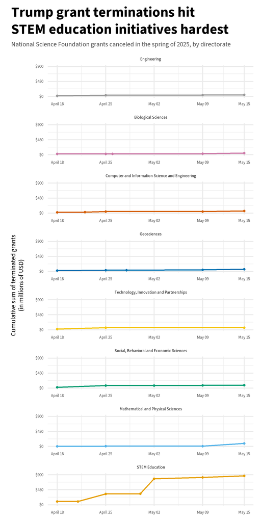

**Raw count terminated plot**

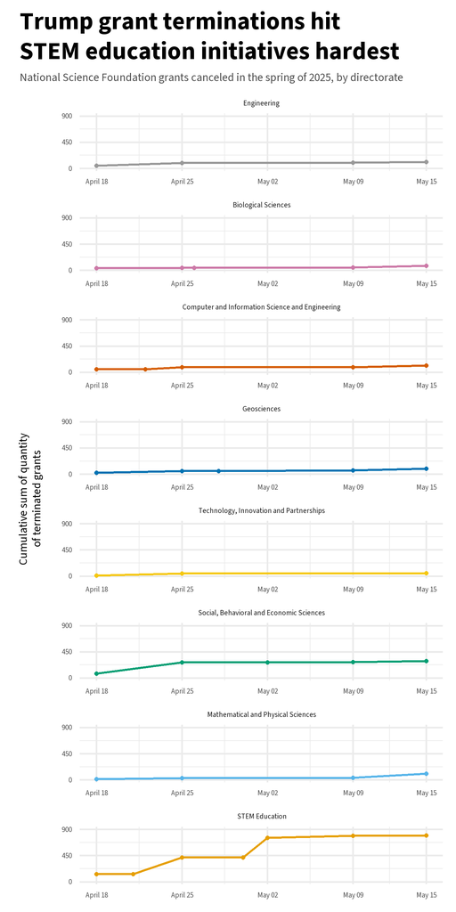

**Accessibility note**

Alt text also embedded in source code for enhanced screen-reading capability. Color palette utilizes Okabe-Ito scheme for increased differentiation for colorblind viewers.

### Discussion

Contrastingly, most STEM fields/directorates, such as Engineering, Geosciences, and Biological Sciences saw much fewer grant terminations, usually hovering between $50 and $100 million in terminated value or about 100 grants terminated by the end of the depicted timeframe. The trends for these fields mirror each other closely when examining the time-series element of the plot, with most terminations occurring between April 18 and April 25, with much fewer occurring between April 25 and May 15. The main deviant from this trend was the Mathematical and Physical Sciences directorate, which did not see major terminations until May 15, demonstrating a back-loaded trend.

Finally, variation in the Social, Behavioral and Economic Sciences (SBES) directorate is important to note, especially in comparing the two presented plots. While the line plots for every other directorate mirror each other between the raw count and dollar value plots, this is not the case with SBES. While the dollar value terminated for this directorate sums to about $100 million by the end of the depicted timeframe, the quantity of grants terminated is much higher, around 250. This suggests that the average value of grants terminated for SBES is much lower than grants for every other directorate. I see two possible causes of this: first, maybe this NSF directorate chose to cancel smaller grants and retain large grants to minimize impact, or second, maybe the average value of grants is actually lower for the SBES field. Either way, this variation begs interesting questions.

## Question 2

**Were grant terminations clustered by geography or motivated by states’ political leanings?**

### Introduction

Variation in state implementation of local and federal policies motivated this question, which asks how grant terminations vary by geography. It also includes examining how these terminations vary by state partisanship. This is especially prevalent in an era where partisan polarization within the United States is record high and states are serving as laboratories of democracy (or authoritarianism) moreso now than ever before due to slashes to the scope of the federal government. Analyzing the role of state partisanship helps reveal correlations between grant cuts and political leanings of states, thereby informing understanding of whether pro-Trump or Republican states receive more lenient consideration in grant terminations or whether Democratic states see higher rates of grant terminations. To answer these questions, the primary dataset was subsetted to include the variables, the state the organization receiving the NSF grant is in (`org_state`) and the dollar value of grants terminated (`usaspending_obligated`). Two additional datasets were also merged to help add needed variables. These datasets added the variables, average annual grant allocation (`total_open_avgperstate`) and a binary variable indicating the state’s partisanship (`vote_trump`).

This question interests me for two main reasons. First, as a public policy student, the geographic implications of policy choices are fascinating to me. The United States has a very interesting division of policy making responsibility between the state and federal governments, and understanding the heterogeneity in how federal policies play out in state arenas is critical to understanding the groups advantaged or disadvantaged by policies. Separately, I wanted to put my map-plotting skills to the test because I will be needing to create some maps for my Master’s capstone project, and wanted to ensure I could create similar visualizations. With regards to my findings in response to this question, I hypothesize that there will be mostly homogeneity in the proportion of grants terminated by state, with maybe a few Democratic state outliers (given the presence of large universities and research institutions in some of these states like California).

### Approach

To respond to this question, I utilized a choropleth because of their ability to effectively communicate geographic patterns and allow for easy comparison between geographies. While cartograms possess similar characteristics—if not better abilities to compare geographies—I find that interpreting cartograms on viewers is more taxing as familiar geographies (i.e. states) are not in familiar positions. In designing this plot, I considered:

- Color mapping. I mapped color to two separate variables through hue and value. Hue is mapped to a state’s partisanship, and uses colors traditionally associated with the Democratic (blue) and Republican (red) parties to ease viewing and not contradict familiar associations. While I considered utilizing a more colorblind-friendly palette, I ultimately considered that diverging from this long-held tradition would be confusing, and used colorblind-friendly hues of red and blue instead. Value is mapped to the proportion of average annual grant funding terminated, and is depicted with a diverging scale from white to red/blue, depending on the state’s partisanship. Proportions range from 0% to 0.8%.
- Measuring proportion of grant funding terminated: First, the primary dataset was collapsed to measure total value of grants terminated by state. A second dataset was then merged onto the primary dataset, the NSF Grants dataset. The NSF Grants dataset is derived from NSF by the Numbers, the National Science Foundation’s statistics and database portal, including information on funding information for grant awards, funded institutions and organizations, proposals for funding, and obligated spending per year since fiscal year 2011. This dataset was first grouped by state and year to calculate total grants allocated to each state each year, then collapsed to retain the average grant allocation to each state over years. Using both these datasets, grant terminations was divided by average annual allocations to provide the proportion used in the creation of the plot. The proportion was set negative for Republican states to create the diverging colorbar.
- Measuring partisanship: A state’s partisanship is measured through the use of a proxy variable, the candidate for which a majority of a state’s electoral votes were allocated to in the 2024 presidential election. This variable was drawn from the State Partisanship dataset, which is adopted from the [CNN Politics](https://www.cnn.com/election/2024/results/president?election-data-id=2024-PG&election-painting-mode=projection-with-lead&filter-key-races=false&filter-flipped=false&filter-remaining=false)’ reporting on the 2024 presidential election, and details the candidate who won the electoral votes of each state.
- Base map creation: The base map was created utilizing the `tigris` package. The state geometries for Alaska and Hawaii were then transformed to resize the two states and move them closer to the continental U.S.

### Analysis

**Plot code**

```r
# Plot
term_map |>
  ggplot()+
  geom_sf(aes(fill = cancel_ratio_perc), color = "black") +
  coord_sf(clip = "off") +
  labs(
    title = "Massachusetts and D.C.lost greatest proportions\nof grant funding in Trump terminations",
    subtitle = "Severity of  National Science Foundation grant terminations, by state partisanship",
    fill = "Proportion of terminated\ngrants relative to\naverage annual allocation\n(diverging on state partisanship)",
      ) +
  scale_fill_gradient2(
    low = "#BB1C1C",
    mid = "white",
    high = "#0072B2",
  labels = function(x)
    label_number(suffix = "%", accuracy = 0.1)
    (abs(x)),
    limits = c(-0.8, 0.8)
    ) +
  guides(fill = guide_colorbar(ticks.colour = NA)) +
  theme(plot.title.position = "plot",
        plot.title = element_text(
         face = "bold",
         size = 45,
         lineheight = 0.5),
        legend.title = element_text(
          lineheight = 0.5,
          color = "#4f4f4f"),
        legend.text = element_text(color = "#4f4f4f"),
        plot.subtitle = element_text(color = "#4f4f4f", size = 25),
       )
```

**Northeast detail code**

```r
# Plot
term_map |>
  ggplot()+
  geom_sf(aes(fill = cancel_ratio_perc), color = "black") +
  coord_sf(xlim = c(-79, -69), ylim = c(37, 44), expand = FALSE, clip = "on") +
  labs(
    title = "Massachusetts and D.C.lost greatest proportions\nof grant funding in Trump terminations",
    subtitle = "Severity of  National Science Foundation grant terminations, by partisanship",
    fill = "Proportion of terminated\ngrants relative to\naverage annual allocation\n(diverging on state partisanship)",
      ) +
  scale_fill_gradient2(
    low = "#BB1C1C",
    mid = "white",
    high = "#0072B2",
  labels = function(x)
    label_number(suffix = "%", accuracy = 0.1)
    (abs(x)),
    limits = c(-0.8, 0.8)
    ) +
  guides(fill = guide_colorbar(ticks.colour = NA)) +
  theme(plot.title.position = "plot",
        plot.title = element_text(
         face = "bold",
         size = 45,
         lineheight = 0.5),
        legend.title = element_text(
          lineheight = 0.5,
          color = "#4f4f4f"),
        legend.text = element_text(color = "#4f4f4f"),
        plot.subtitle = element_text(color = "#4f4f4f", size = 25),
       )
```

### Visualizations

**Plot**

[figure not shown]

**Northeast detail**

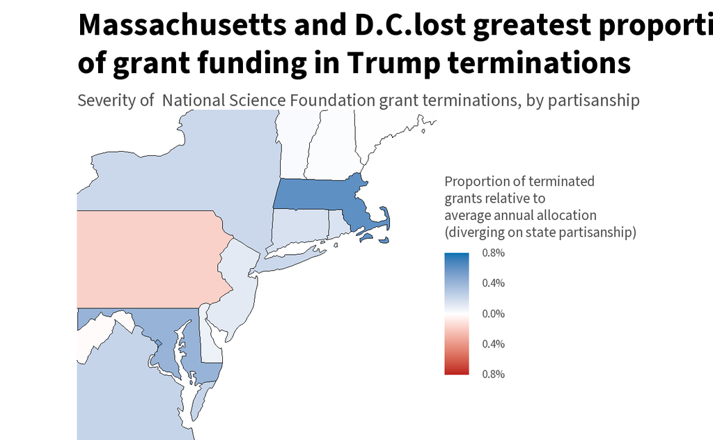

**Accessibility note**

Alt text also embedded in source code for enhanced screen-reading capability. Coloring of colorbar and gradient utilize colorblind friendly colors.

### Discussion

When looking at Democratic-leaning states, a few jump out: Massachusetts, Maryland, and the District of Columbia. Each of these entities lost 0.62%, 0.41%, and 0.51% of average annual grant funding, respectively. One interpretation of the root of these higher proportions of cut funding in these states could rely on the high quantity of universities and research institutions in each of these three states. Harvard University, located in Massachusetts, has gained media attention for its pushback against Trump Administration attacks, garnering cut funding to the University. Other major research institutions are located in these states including MIT and Johns Hopkins. Many research organizations, associations, and universities are housed in the District of Columbia as well, potentially giving reason to the terminated grants in this entity.

Examining Republican-leaning states reveals a different story, however. Alabama and Arkansas are the two red states with the greatest proportion of terminated grants, 0.49 and 0.43 percent, respectively. Unlike the aforementioned blue states, neither of these states houses major research institutions; indeed, the institutions who lost the grant funding were state universities (the University of Alabama and the University of Arkansas, respectively). Unfortunately, both of these universities were engaged in a lot of initiatives housed under the STEM Education and Social, Behavioral and Economic Sciences directorates—the two greatest impacted directorates as examined in Question 1. Another interpretation of the data mapped to these states is that as smaller states receive less grant funding (in the 2-5 billion dollar annual average instead of in the tens of billions of dollars), these states are more vulnerable to smaller grant terminations.

## Conclusion: limitations and further directions

Ultimately, both of these visualizations provide unique frameworks for examining National Science Foundation grant terminations in the spring of 2025. Faceting by directorate and color-mapping by state partisanship help visualize the areas (e.g. scientific domains and geographic entities) most impacted by the Trump Administration’s grant terminations.

Further analysis could include a more rigorous statistical examination of the state attributes most likely to impact grant terminations or organizational grant terminations through the implementation of an OLS model. Similarly, examining differences in trends between raw and summarized/proportional data was one decision-making area which I would expand on in further exploration. I attempted to tease out differences in relationships as much as possible in Question 1 by showing dollar value versus raw count in two separate plots, however examining proportions of total funding cut by directorate would make for interesting analysis as well, especially as funding is likely not equal between directorates. Similarly, there may be better methods to quantify the independent variable examined in Question 2. I wanted to standardize grant terminations across states somehow (so that larger, more populous states would not be seen as having more grants terminated solely due to their size), and I was able to accomplish this by averaging annual grant allocations, however there may be a better standardization method. Finally, continuing to examine these trends as more grants are cut is critical to documenting the Trump Administration’s attacks on education and academia. This dataset solely encompasses grants cut between April 18 and May 15, however as more data becomes available, trends must continue to be analyzed.